# week_7_excercises_data

J.Blondeau

2024-10-03

This week is all about making plots and graphs in ggplot2. The only datasets you need are in the /data directory.

1. sttstj_fish_biomass
2. taxonomic

In this instance, anytime you need to group by and summarize, you can just take the mean of biomass and SE. This would not always be appropriate, but for this case the exercises are for plotting and graphing.

**put all your code in the .Rmd file inside a code chunk for each question. Annotate what you are doing so that you can reference them later.

1. Create a line graph of biomass over time for Red hind (“EPI GUTT”) inside the national park.

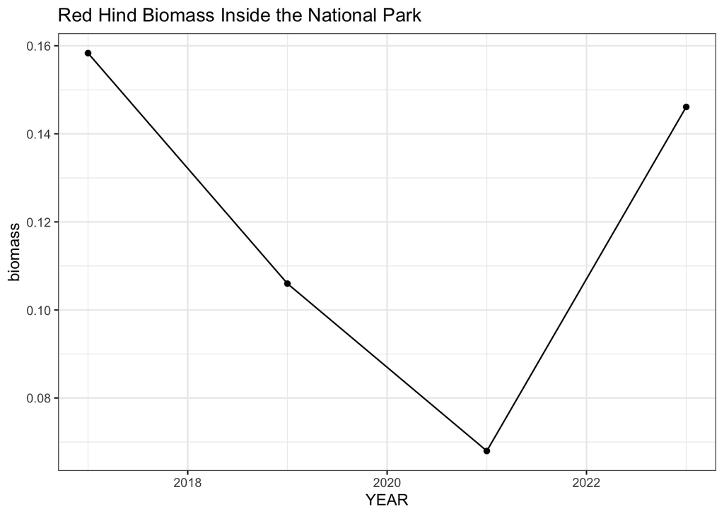

2. Create a point and line graph of biomass over time for Yellowtail Snapper (“OCY CHRY”) outside the national park.

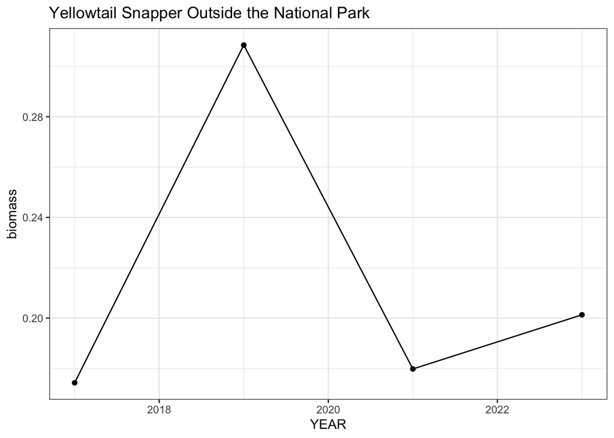

3. Create a bar graph of biomass over time for each species grouped by protected_status. Edit the the axis and legend titles to be more insightful.
   - biomass units
   - 0 = Open, 1 = VI National Park

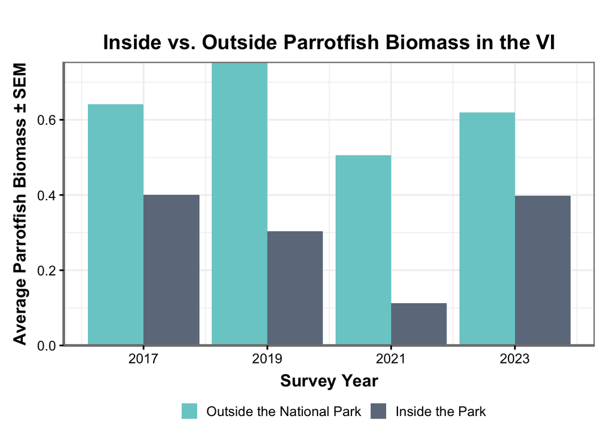

4. Create a bar graph of trophic-level mean biomass inside and outside VI national park for each species.

[figure not shown]

5. Create a point and line plot of ‘grouper’ biomass (+- SE) over time; inside and outside park together.

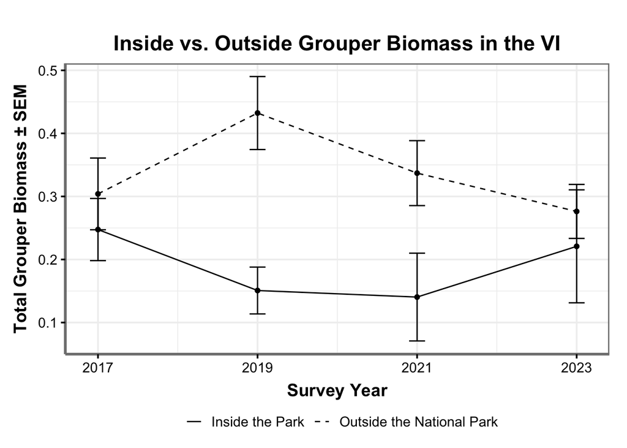